# Deliverable 3: Preprocessing

## Histogram of Available and Rentable Square Footage

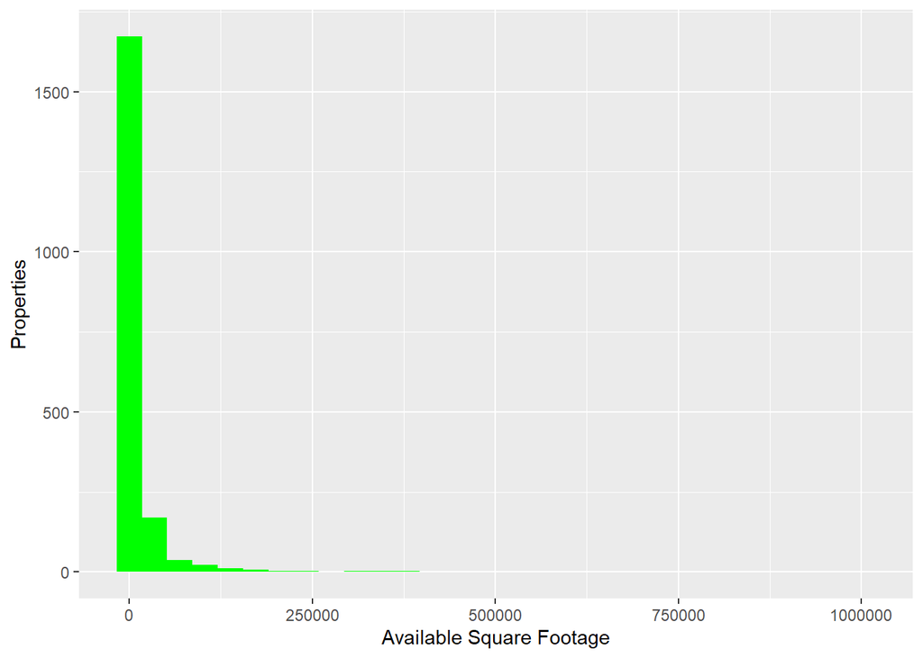

```r
ggplot(IOLP.all)+geom_histogram(aes(x = Available.Square.Feet,),fill="green") + labs(x= "Available Square Footage", y="Properties")
```

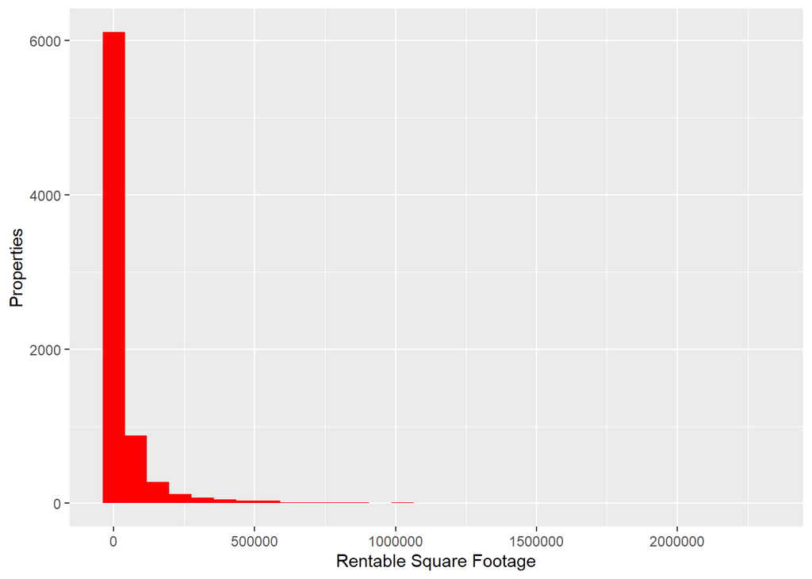

```r
ggplot(IOLP.all)+geom_histogram(aes(x = Building.Rentable.Square.Feet),fill="red")+labs(x="Rentable Square Footage", y="Properties")
```

> These are simple histograms showing the comparison between the square footage of total properties. Strangely, it seems that they both follow a simmilar pattern, with many of the properties having no rentable or available square footage. However, upon seeing these graphs, I now understand that this lack of rentable or vacant property more likely reflects the efficiant use of government properties, as there is very little property being rented commercially or marked as “vacant”.